# SW chap10 Panel Data

# ==============================================================================

# Data Analysis Tutorial: Panel data models

# ==============================================================================

# Original: Bill Sundstrom 6/20/2015 # Current version: Bill Sundstrom 6/29/2016

# Description: Panel data using examples from S&W ch. 10 # Also clustering SEs

# ==============================================================================

# 1. Settings, packages, and options (run these every R session)

# ==============================================================================

# Clear the working space

```r
  library(ivpack)
```

```r
### functions for correct SEs in regression tables
  # function to calculate corrected SEs for OLS regression
  cse = function(reg) {
    rob = sqrt(diag(vcovHC(reg, type = "HC1")))
    return(rob)
  }

  # clustered SEs, clustered on "group"... could also cluster on "time"
  # compute Stata-like degrees of freedom adjustment for number of groups
  # See http://www.richard-bluhm.com/clustered-ses-in-r-and-stata-2/

  clse = function(reg) {
    # index(reg, "id") returns the id or entity variable vector
    G = length(unique(index(reg,"id")))
    N = length(index(reg,"id"))
    dfa = (G/(G - 1))   # note Bluhm multiplies this by finite-sample df adjustment
    rob = sqrt(diag(dfa*vcovHC(reg, method="arellano", type = "HC1",
                               cluster = "group")))
    return(rob)
  }

  # corrected SEs for IV regressions
  ivse = function(reg) {
    rob = robust.se(reg)[,2]
    return(rob)
  }
```

# ==============================================================================

# 2. Data section for panel regressions

# ==============================================================================

### Read the data set (AER package)

```r
  data("Fatalities")

  # units used in SW
  # vehicle fatality rate (vehicle fatalities/ population)
  Fatalities$mrall=Fatalities$fatal/Fatalities$pop
  # fatality rate per 10000
  Fatalities$fatality_rate = Fatalities$mrall*10000

  # descriptive statistics
  stargazer(Fatalities, type="text", median=TRUE,
            digits=2, title="Traffic Fatalities Data")
```

```
Traffic Fatalities Data
=================================================================================
Statistic      N      Mean       St. Dev.      Min        Median         Max
---------------------------------------------------------------------------------
spirits       336     1.75         0.68        0.79        1.67         4.90
unemp         336     7.35         2.53        2.40        7.00         18.00
income        336  13,880.18     2,253.05    9,513.76   13,763.13     22,193.46
emppop        336    60.81         4.72       42.99       61.36         71.27
beertax       336     0.51         0.48        0.04        0.35         2.72
baptist       336     7.16         9.76        0.00        1.75         30.36
mormon        336     2.80         9.67        0.10        0.39         65.92
drinkage      336    20.46         0.90       18.00       21.00         21.00
dry           336     4.27         9.50        0.00        0.09         45.79
youngdrivers  336     0.19         0.02        0.07        0.19         0.28
miles         336   7,890.75     1,475.66    4,576.35    7,796.22     26,148.27
fatal         336    928.66       934.05        79         701          5,504
nfatal        336    182.58       188.43        13         135          1,049
sfatal        336    109.95       108.54        8           81           603
fatal1517     336    62.61        55.73         3           49           318
nfatal1517    336    12.26        12.25         0           10           76
fatal1820     336    106.66       104.22        7           82           601
nfatal1820    336    33.53        33.24         0           24           196
fatal2124     336    126.87       131.79        12         97.5          770
nfatal2124    336    41.38        42.93         1           30           249
afatal        336    293.33       303.58      24.60       211.59      2,094.90
pop           336 4,930,272.00 5,073,704.00 478,999.70 3,310,503.00 28,314,028.00
pop1517       336  230,815.50   229,896.30  21,000.02   163,000.20  1,172,000.00
pop1820       336  249,090.40   249,345.60  20,999.96   170,982.30  1,321,004.00
pop2124       336  336,389.90   345,304.40  30,000.16   240,999.90  1,892,998.00
milestot      336  37,101.49    37,454.37    3,993.00   28,483.50    241,575.00
unempus       336     7.53         1.48        5.50        7.20         9.70
emppopus      336    59.97         1.59       57.80       60.10         62.30
gsp           336     0.03         0.04       -0.12        0.03         0.14
mrall         336    0.0002       0.0001      0.0001      0.0002       0.0004
fatality_rate 336     2.04         0.57        0.82        1.96         4.22
---------------------------------------------------------------------------------
```

# ==============================================================================

# 3. Analysis: Panel data and fixed effects estimation using plm

# ==============================================================================

### (a) Simple cross-section regressions for comparison

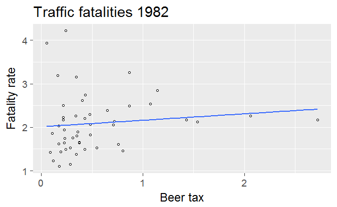

```r
  # Let's plot the data for 1982 and 1988 cross sections, with regression lines
  ggplot(subset(Fatalities, year==1982), aes(x=beertax, y=fatality_rate)) +
    labs(y="Fatality rate", x="Beer tax", title = "Traffic fatalities 1982") +
    geom_point(shape=1) +
    geom_smooth(method=lm, se=F)
```

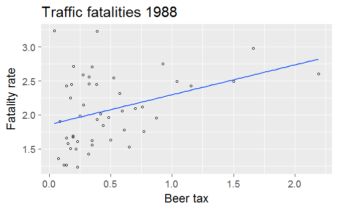

```r
  ggplot(subset(Fatalities, year==1988), aes(x=beertax, y=fatality_rate)) +
    labs(y="Fatality rate", x="Beer tax", title = "Traffic fatalities 1988") +
    geom_point(shape=1) +
    geom_smooth(method=lm, se=F)
```

```r
  # Simple regressions for 1982 and 1988 cross sections, as in SW
  reg1982 = lm(fatality_rate ~ beertax,
               data = subset(Fatalities, year==1982))
  reg1988 = lm(fatality_rate ~ beertax,
               data = subset(Fatalities, year==1988))
  stargazer(reg1982, reg1988,
            se=list(cse(reg1982),cse(reg1988)),
            title="Simple cross-section regressions", type="text",
            column.labels=c("1982", "1988"),
            df=FALSE, digits=4)
```

```
Simple cross-section regressions
================================================
                        Dependent variable:
                    ----------------------------
                           fatality_rate
                         1982          1988
                         (1)            (2)
------------------------------------------------
beertax                 0.1485       0.4388***
                       (0.1326)      (0.1279)

Constant              2.0104***      1.8591***
                       (0.1496)      (0.1146)

------------------------------------------------
Observations              48            48
R2                      0.0133        0.1340
Adjusted R2            -0.0081        0.1152
Residual Std. Error     0.6705        0.4903
F Statistic             0.6212       7.1180**
================================================
Note:                *p<0.1; **p<0.05; ***p<0.01
```

### (b) Panel regressions using plm(…)

# Now we use the full data set, all seven years 1982-1988 # We’ll estimate pooled, fixed-effect (FE), and first-difference (FD) regressions

# In place of lm(…) we use plm(…) # In each plm command index = c(“state”,“year”) means # the first var (state) is the entity and second var (year) is the time variable

### reg1: OLS (pooled), and equivalent to lm(fatality_rate ~ beertax, …)

```r
  reg1 = plm(fatality_rate ~ beertax,
             data = Fatalities, index = c("state","year"), model="pooling")
```

### reg2: state FEs

# In this command, model=“within” is fixed effects (demeaned model), # effect=“individual” means just entity (state) FEs

```r
  reg2 = plm(fatality_rate ~ beertax,
             data = Fatalities, index = c("state","year"),
             model="within", effect="individual")
```

# What is this FE regression doing? Basically it is including a full set of # state dummy variables. We can see this by including state (a factor variable) # as a regressor in OLS

```r
  reg2a = lm(fatality_rate ~ beertax + state,
             data = Fatalities)
```

# compare coefficient (slope) on beertax for FE regression vs dummy-variable version

```r
  stargazer(reg2, reg2a,
            title="State FEs", type="text",
            df=FALSE, digits=4)
```

```
the condition has length > 1 and only the first element will be usednumber of rows of result is not a multiple of vector length (arg 2)
```

```
State FEs
================================================
                        Dependent variable:
                    ----------------------------
                           fatality_rate
                        panel           OLS
                        linear
                         (1)            (2)
------------------------------------------------
beertax               -0.6559***    -0.6559***
                       (0.1878)      (0.1878)

stateaz                              -0.5677**
                                     (0.2667)

statear                             -0.6550***
                                     (0.2190)

stateca                             -1.5095***
                                     (0.3044)

stateco                             -1.4843***
                                     (0.2874)

statect                             -1.8623***
                                     (0.2805)

statede                             -1.3076***
                                     (0.2939)

statefl                              -0.2681*
                                     (0.1393)

statega                              0.5246***
                                     (0.1839)

stateid                             -0.6690***
                                     (0.2580)

stateil                             -1.9616***
```

[output cut: 109 more lines]

```

statewy                               -0.2285
                                     (0.3129)

Constant                             3.4776***
                                     (0.3134)

------------------------------------------------
Observations             336            336
R2                      0.0407        0.9050
Adjusted R2            -0.1197        0.8891
Residual Std. Error                   0.1899
F Statistic           12.1904***    56.9692***
================================================
Note:                *p<0.1; **p<0.05; ***p<0.01
```

### reg3: We can include year FEs as well as state FEs

# effect=“twoways” means both entity and time FEs

```r
  reg3 = plm(fatality_rate ~ beertax,
             data = Fatalities, index = c("state","year"),
             model="within", effect="twoways" )
```

# Now put regs 1,2,3 in a table with SEs clustered by state # We cluster the SEs by state using the clse function

```r
  stargazer(reg1, reg2, reg3,
            se=list(clse(reg1),clse(reg2),clse(reg3)),
            title="Panel regressions, clustered SEs", type="text",
            column.labels=c("Pooled OLS", "State FE", "St-Yr FE"),
            df=FALSE, digits=4)
```

```
the condition has length > 1 and only the first element will be usedthe condition has length > 1 and only the first element will be usedthe condition has length > 1 and only the first element will be used
```

```
Panel regressions, clustered SEs
=============================================
                   Dependent variable:
             --------------------------------
                      fatality_rate
             Pooled OLS  State FE   St-Yr FE
                (1)        (2)        (3)
---------------------------------------------
beertax      0.3646***  -0.6559**   -0.6400*
              (0.1199)   (0.2919)   (0.3539)

Constant     1.8533***
              (0.1187)

---------------------------------------------
Observations    336        336        336
R2             0.0934     0.0407     0.0361
Adjusted R2    0.0906    -0.1197    -0.1492
F Statistic  34.3943*** 12.1904*** 10.5133***
=============================================
Note:             *p<0.1; **p<0.05; ***p<0.01
```

# compare unadjusted and clustered SEs for reg2: clustering matters!

```r
  stargazer(reg2a, reg2,
            se=list(cse(reg2a),clse(reg2)),
            title="FE regressions", type="text",
            column.labels=c("no cluster", "clustered"),
            keep=c("beertax"),  # the keep option shows only selected coefficients in table
            df=FALSE, digits=4)
```

```
the condition has length > 1 and only the first element will be used
```

```
FE regressions
================================================
                        Dependent variable:
                    ----------------------------
                           fatality_rate
                         OLS           panel
                                      linear
                      no cluster     clustered
                         (1)            (2)
------------------------------------------------
beertax               -0.6559***     -0.6559**
                       (0.2033)      (0.2919)

------------------------------------------------
Observations             336            336
R2                      0.9050        0.0407
Adjusted R2             0.8891        -0.1197
Residual Std. Error     0.1899
F Statistic           56.9692***    12.1904***
================================================
Note:                *p<0.1; **p<0.05; ***p<0.01
```

### reg4: We can also run the model in first differences

```r
  reg4 = plm(fatality_rate ~ beertax,
             data = Fatalities, index = c("state","year"), model="fd")
```

#### This should compare with reg2 (state FEs)

```r
  stargazer(reg2, reg4,
            se=list(clse(reg2),clse(reg4)),
            title="FE vs FD", type="text",
            column.labels=c("FE", "FD"),
            df=FALSE, digits=4)
```

```
the condition has length > 1 and only the first element will be usedthe condition has length > 1 and only the first element will be usednumber of rows of result is not a multiple of vector length (arg 2)
```

```
FE vs FD
=========================================
                 Dependent variable:
             ----------------------------
                    fatality_rate
                   FE             FD
                   (1)           (2)
-----------------------------------------
beertax         -0.6559**       0.0137
                (0.2919)       (0.2608)

Constant                       -0.0031
                               (0.0099)

-----------------------------------------
Observations       336           288
R2               0.0407        0.00001
Adjusted R2      -0.1197       -0.0035
F Statistic    12.1904***       0.0023
=========================================
Note:         *p<0.1; **p<0.05; ***p<0.01
```

# Note that the results are not very similar! This can indicate a problem.

# You could add year effects to fd, but need to create the year dummies “by hand”

```r
  Fatalities <- mutate(Fatalities,
                       y83 = as.numeric(year==1983),
                       y84 = as.numeric(year==1984),
                       y85 = as.numeric(year==1985),
                       y86 = as.numeric(year==1986),
                       y87 = as.numeric(year==1987),
                       y88 = as.numeric(year==1988))
```

```r
  reg4a = plm(fatality_rate ~ beertax + y84+y85+y86+y87+y88,
             data = Fatalities, index = c("state","year"),
             model="fd" )
  stargazer(reg4, reg4a,
            se=list(clse(reg4),clse(reg4a)),
            title="FD with and without year effects", type="text",
            column.labels=c("without", "with"),
            df=FALSE, digits=4)
```

```
the condition has length > 1 and only the first element will be usedthe condition has length > 1 and only the first element will be usednumber of rows of result is not a multiple of vector length (arg 2)
```

```
FD with and without year effects
=========================================
                 Dependent variable:
             ----------------------------
                    fatality_rate
                without         with
                  (1)            (2)
-----------------------------------------
beertax          0.0137        0.0797
                (0.2608)      (0.2815)

y84                            0.0909*
                              (0.0467)

y85                            0.1299*
                              (0.0751)

y86                           0.3034***
                              (0.1040)

y87                           0.3815***
                              (0.1266)

y88                           0.4731***
                              (0.1643)

Constant        -0.0031       -0.0814**
                (0.0099)      (0.0321)

-----------------------------------------
Observations      288            288
R2              0.00001        0.0729
Adjusted R2     -0.0035        0.0531
F Statistic      0.0023       3.6823***
=========================================
Note:         *p<0.1; **p<0.05; ***p<0.01
```

### Adding more regressors

# Note we can run models with more variables, such as spirits (spirits consumption) # They must be variables that are time-varying within state

```r
  reg3a = plm(fatality_rate ~ beertax + spirits,
              data = Fatalities, index = c("state","year"),
              effect="twoways", model="within")
  stargazer(reg3, reg3a,
            se=list(clse(reg3),clse(reg3a)),
            title="Fixed-effect regressions", type="text",
            df=FALSE, digits=4)
```

```
the condition has length > 1 and only the first element will be usedthe condition has length > 1 and only the first element will be usednumber of rows of result is not a multiple of vector length (arg 2)
```

```
Fixed-effect regressions
=========================================
                 Dependent variable:
             ----------------------------
                    fatality_rate
                  (1)            (2)
-----------------------------------------
beertax         -0.6400*      -0.4924*
                (0.3539)      (0.2736)

spirits                       1.0273***
                              (0.1818)

-----------------------------------------
Observations      336            336
R2               0.0361        0.2249
Adjusted R2     -0.1492        0.0726
F Statistic    10.5133***    40.6222***
=========================================
Note:         *p<0.1; **p<0.05; ***p<0.01
```

### Extract the fixed effects (as deviations from intercept)

# Sometimes we would like to retrieve the fixed effects coefficients, # as if we had run the regression with dummy variables for state and time

# this can be done after plm with the function fixef

```r
  fixef(reg3a,effect="individual")
```

```
         al          az          ar          ca          co          ct
 1.90461673  0.94389435  1.60346175 -0.06548257 -0.08245675 -0.83074297
         de          fl          ga          id          il          in
-0.41623639  0.66730892  1.68521855  1.51680644 -0.39745307  0.58245094
         ia          ks          ky          la          me          md
 0.73740112  0.97271145  0.92525042  0.86275810  0.32121274 -0.55795066
         ma          mi          mn          ms          mo          mt
-1.07357019  0.08158385 -0.47660150  1.88616393  0.77305445  1.35561040
         ne          nv          nh          nj          nm          ny
 0.45434632 -1.66429004 -2.26325117 -0.80149232  2.39888657 -0.71396261
         nc          nd          oh          ok          or          pa
 1.44801240 -0.07113100  0.53388910  1.45819816  0.71953039  0.35910816
         ri          sc          sd          tn          tx          ut
-0.87195752  1.85692710  0.68479404  1.23306299  1.12154034  1.30671841
         vt          va          wa          wv          wi          wy
 0.22793658  0.52202373  0.05714054  1.62609312 -0.30435710  1.36130660
```

```r
  fixef(reg3a,effect="time")
```

```
     1982      1983      1984      1985      1986      1987      1988
0.3716133 0.3378399 0.3891817 0.3989919 0.6128086 0.6417898 0.6891619
```

# save the fixed effects and examine selected values

```r
  ife <- fixef(reg3a,effect="individual")
  ife[c("al","ny")]
```

```
        al         ny
 1.9046167 -0.7139626
```